# Лабораторная работа №5

Архитектура компьютера и операционные системы

Кобзев Д. К.

Российский университет дружбы народов, Москва, Россия

# Информация

## Докладчик

- Кобзев Дмитрий Константинович
- студент
- прикладная информатика
- Российский университет дружбы народов
- 1132231936@rudn.ru

# Менеджер паролей pass

## Установка

- Устанавливаем менеджер паролей pass

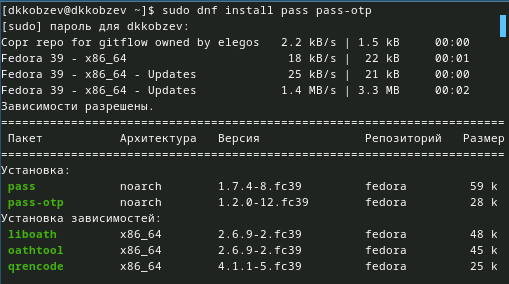

## Установка

- Устанавливаем менеджер паролей pass

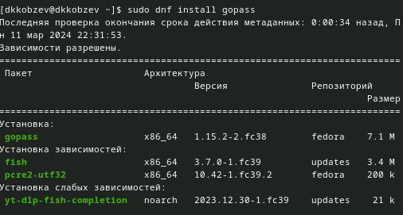

## Настройка

- Просматриваем список ключей и инициализируем хранилище

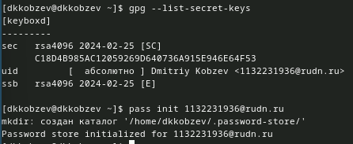

## Настройка

- Создаем репозиторий

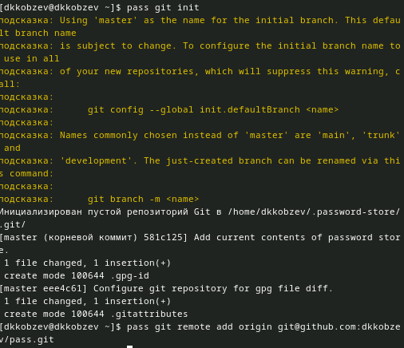

## Настройка

- Создаем структуру git и задаем адрес репозитория на хостинге

[figure not shown]

## Настройка

- Синхронизируем

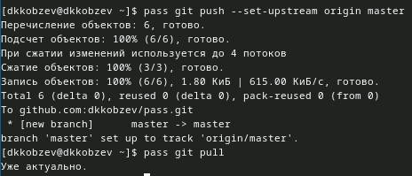

## Настройка

- Коммитим и выкладываем изменениия

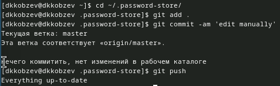

## Настройка

- Проверяем статус синхронизации

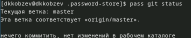

## Настройка интерфейса с броузером

- Устанавливаем browserpass

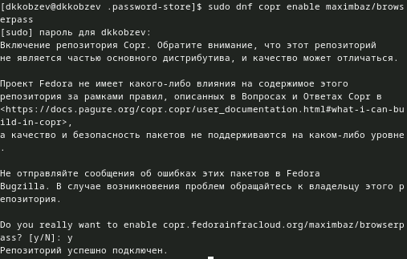

## Настройка интерфейса с броузером

- Устанавливаем browserpass

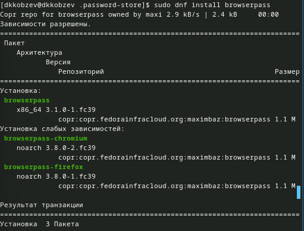

## Настройка интерфейса с броузером

- Устанавливаем browserpass

[figure not shown]

## Настройка интерфейса с броузером

- Добавляем новый пароль

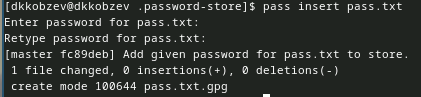

## Настройка интерфейса с броузером

- Меняем существующий пароль

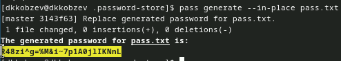

# Управление файлами конфигурации и дополнительное программное обеспечение

- Устанавливаем дополнительное ПО

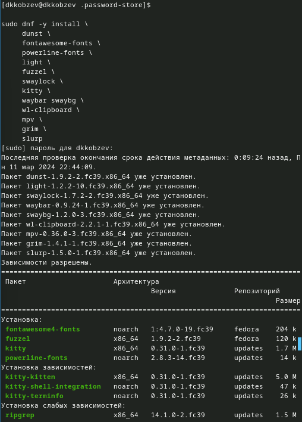

## Управление файлами конфигурации и дополнительное программное обеспечение

- Устанавливаем шрифты

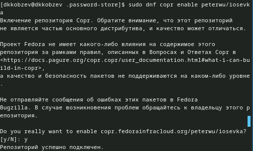

## Управление файлами конфигурации и дополнительное программное обеспечение

- Устанавливаем шрифты

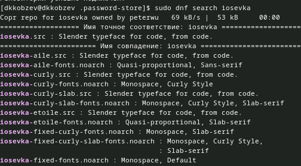

## Управление файлами конфигурации и дополнительное программное обеспечение

- Устанавливаем шрифты

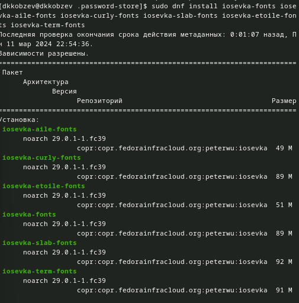

## Установка

- Устанавливаем бинарный файл

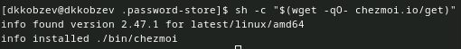

## Подключение репозитория к своей системе

- Инициализируем chezmoi с нашим репозиторией dotfiles, проверяем, какие изменения внесет chezmoi в домашний каталог и подтверждаем изменения

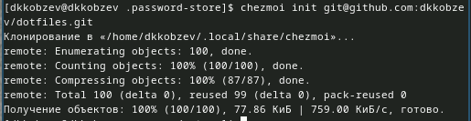

## Использование chezmoi на нескольких машинах

- На второй машине инициализируем chezmoi с нашим репозиторией dotfiles, проверяем, какие изменения внесет chezmoi в домашний каталог и подтверждаем изменения

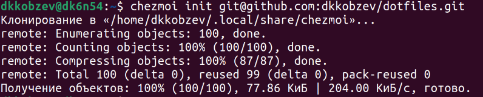

## Использование chezmoi на нескольких машинах и настройка новой машины с помощью одной команды

- Получаем и применяем последние изменения из нашего репозитория и устанавливаем свои dotfiles на новый компьютер

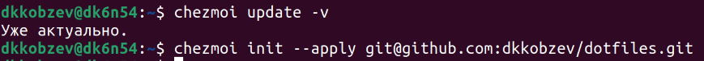

## Ежедневный операции с chezmoi

- Извлекаем изменения из репозитория и применяем их одной командой и извлекаем последние изменения из своего репозитория и смотрим, что изменится

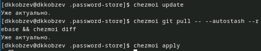

## Ежедневный операции с chezmoi

- Редактируем файл конфигурации ~/.config/chezmoi/chezmoi.toml